# MUM 2024-25 Architektura modelu U-Net

## założenia U-Net [[Ronneberger, Fischer, Brox, U-Net: convolutional networks for biomedical image segmentation, 2015]](https://arxiv.org/pdf/1505.04597v1.pdf)

- architektury wymagają bardzo wielu przykładów, aby rozpoznać kontekst oraz szczegóły

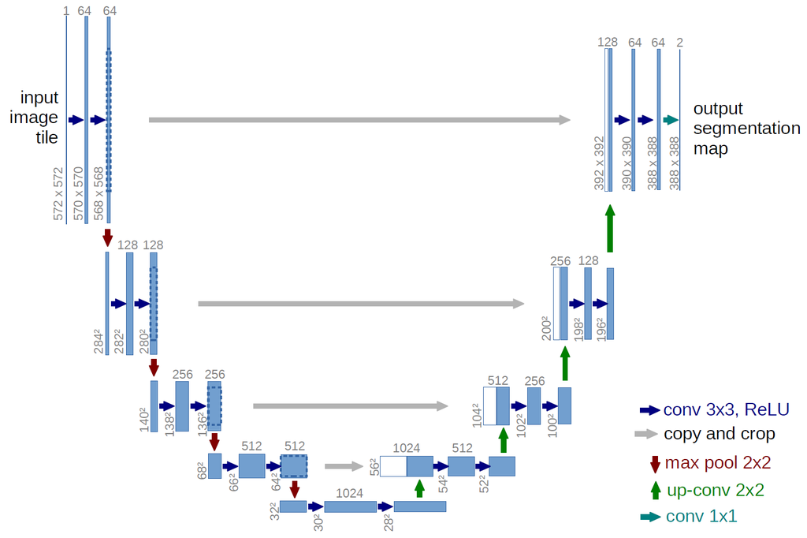

  - symetryczna architektura konwolucyjna
    - początkowo zawężająca dla rozpoznania kontekstu
    - symetryczna dla lokalizacji każdego z elementów
    - symetryczne wykorzystanie na wielu poziomach
- celem jest też klasyfikacja — przypisanie każdemu pikselowi klasy -- efektywnie **segmentacja**
  - szczególnie dla zadań biomedycznych
  - inne architektury wykorzystują wiele patchy, o różnych wymiarach, które wszystkie są klasyfikowane
    - może być bardzo powolne

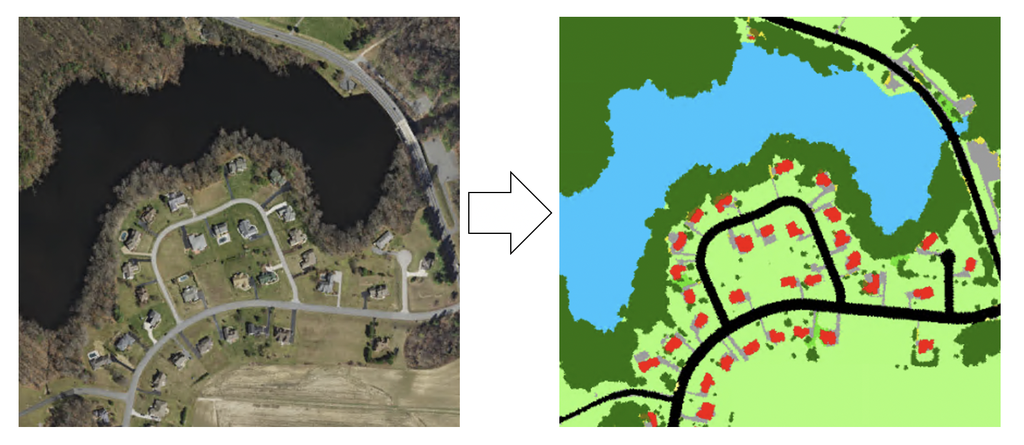

- strona zawężająca
  - konwolucje 3x3 z aktywacjami ReLU
  - pooling 2x2 ze stride 2 zmniejszający obraz dwukrotnie
    - opis jak w oryginalnej architekturze , możliwe modyfikacje
  - każdemu zmniejszeniu towarzyszy dwukrotne zwiększenie liczby kanałów

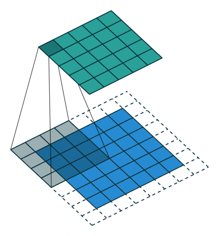

- część rozszerzająca
  - operacja poolingu jest zastąpiona przez **upsampling** (up-convolution, deconvolution, transposed-convolution -- najlepsze) 2x2
    - w najprostszym rozwiązaniu jest zastąpieniem każdego piksela okienkiem o wielkości powiększającej ustaloną liczbę razy (`scale_factor` w PyTorch) ( metoda **nearest-neighbour**)
      - także `bilinear`, `bicubic`, etc. [[Upsample]](https://pytorch.org/docs/stable/generated/torch.nn.Upsample.html)
    - konwolucje 3x3 z ReLU
    - następnie konwolucje 2x2, która zmniejsza dwukrotnie liczbę kanałów
- upsampling nie jest "przeciwieństwem" pooling i jest operacją rzadką, może gubić kontekst
  - potrzebny jest *prior*
  - konkatenujemy obraz z części zawężającej
  - ze względu na utratę brzegów, obraz z lewej części jest redukowany na brzegach
  - alternatywą może być odpowiednie użycie paddingu
- w ostatniej warstwie konwolucje 1x1 dla uzyskania odpowiedniej liczby klas
- bardzo dobre efekty

## Uczenie

- uczenie gradientowe z entropią krzyżową jako funkcją kosztu $$L=\sum_{x\in\Omega}w(x)\log(p_{l(x)}(x))$$ gdzie $x\in\Omega$ jest pikselem, $\Omega$ zbiorem indeksów na obrazie, a $l:\omega\rightarrow\{1,\dots,K\}$ etykietami prawidłowej klasy
- $w:\Omega\rightarrow\mathbb{R}$ jest wagą przypisującą niektórym pikselom **większą istotność**
  - dla prawdziwych segmentacji liczona jest waga dla zrównoważenia $$w(x)=w_c(x)+w_0\exp\left(-\dfrac{(d_1(x)+d_2(x))^2}{2\sigma^2}\right)$$
    - różnych kolorów pikseli w tej samej klasie $w_c$
    - pikseli dla wąskich brzegów między obiektami z różnych klas dla $d_1$ - odległości piksela do brzegu najbliższej komórki, $d_2$ - odległość do brzegu drugiej najbliższej komórki

### Augmentacja danych

- dla dobrego uczenia konieczna jest augmentacja danych
  - dla obrazów biomedycznych przesunięcia, obroty
  - szczególnie drobne losowe elastyczne deformacje pozwalają na uczenie na małych batchach danych
- przy wykorzystaniu augmentacji algorytm uczenia, na małych batchach, uczy sie bardzo szybko